# Ceci n’est pas une %>%: Exploring Your Data with R

Fall 2015 Workshop  
Michael Clark  
Consulting for Statistics, Computing & Analytyics Research  
Advanced Research Computing

## Preliminaries

Link to slides:  
www-personal.umich.edu/~micl/mainSlides.html

Link to R package install/load script:  
www-personal.umich.edu/~micl/installLoadPackages.R

- Start Rstudio
- Run script (make take a couple minutes)
- Copy, paste, and run or run the following:
- source("http://www-personal.umich.edu/~micl/installLoadPackages.R")

YOU WILL GET A POP-UNDER WINDOW (on the Windows lab machines). Affirm that you want to use a personal library.

## The Reference

**The Treachery of Images** by Rene Magritte

## Goals

- Introduce newer approaches to data wranging, scrubbing, manipulation etc.
- Show the benefits of *piping* code
- Put it all together with some newer visualization packages

## Outline

Newer approaches to data wrangling

- Introduction to plyr dplyr and tidyr
- Subsetting rows
- Subsetting columns
- Reshaping data
- Generating new data
- Grouping and summarizing

Nothin's gonna stop the flow

- More piping with the magrittr package

Quick interactive visualizations

- ggvis, htmlwidgets

## Newer approaches to data wrangling

## Newer approaches to data wrangling

A starting example

Let's say we want to select from our data the following variables

- Start with the **ID** variable
- The variables **X1:X10**, which are not all together, and there are many more *X* columns
- The variables **var1** and **var2**, which are the only *var* variables in the data
- Any variable that starts with **XYZ**

How might we go about this?

## Some base R approaches

Tedious, or typically two steps just to get the columns you want.

```r
# numeric indexes; not conducive to readibility or reproducibility
newData = oldData[,c(1,2,3,4, etc.)]

# explicitly by name; fine if only a handful; not pretty
newData = oldData[,c('ID','X1', 'X2', etc.)]

# two step with grep; regex difficult to read/understand
cols = c('ID', paste0('X', 1:10), 'var1', 'var2', grep(colnames(oldData), '^XYZ', value=T))
newData = oldData[,cols]

# or via subset
newData = subset(oldData, select = cols)
```

## More

What if you also want observations where **Z** is **Yes**, Q is **No**, and only the last 50 of those results, ordered by **var1** (descending)?

```r
# three operations and overwriting or creating new objects if we want clarity
newData = newData[oldData$Z == 'Yes' & oldData$Q == 'No',]
newData = tail(newData, 50)
newData = newdata[order(newdata$var1, decreasing=T),]
```

And this is for fairly straightforward operations.

## An alternative

```r
newData = oldData %>%
  filter(Z == 'Yes', Q == 'No') %>%
  select(num_range('X', 1:10), contains('var'), starts_with('XYZ')) %>%
  tail(50) %>%
  arrange(desc(var1))
```

## An alternative

Even though the initial base R approach depicted is probably more concise than many would do on their own, it still is:

- noisier
- less legible
- less amenable to additional data changes
- requires esoteric knowledge (e.g. regular expressions)
- often requires new objects (even if we just want to explore)

## Another example…

## Start with a string, end with a map

```r
wikiURL = 'https://en.wikipedia.org/wiki/List_of_United_States_cities_by_population'

# Let's go!
wikiURL %>%
  read_html %>%                                                                     # parse the html
  html_node(css='.wikitable.sortable') %>%                                          # grab a class of object
  html_table %>%                                                                    # convert table to data.frame
  sapply(function(x) repair_encoding(as.character(x), 'UTF-8')) %>%                 # repair encoding; makes a matrix
  data.frame %>%                                                                    # back to df
  mutate(City = str_replace(City, '\\[(.*?)\\]', ''),                               # remove footnotes
         latlon = sapply(str_split(Location, '/'), last),                           # split up location (3 parts)
         latlon = str_extract_all(latlon, '[-|[0-9]]+\\.[0-9]+'),                   # grab any that start with - or number
         lat = sapply(latlon, first),                                               # grab latitudes
         lon = sapply(latlon, nth, 2),                                              # grab longitude
         population2014 = as.numeric(str_replace_all(X2014.estimate, ',', '')),     # remove commas from numbers (why do people do this?)
         population2010 = as.numeric(str_replace_all(X2010.Census, ',', '')),       # same for 2010
         popDiff  = round(population2014/population2010 - 1, 2)*100) %>%            # create percentage difference
```

## Cont'd.

```r
  select(-latlon, -Location) %>%                                                    # remove stuff we wouldn't ever use
  filter(as.numeric(as.character(X2014.rank)) <= 50)  %>%                           # top 50
  leaflet %>%                                                                       # map out
  addProviderTiles("CartoDB.DarkMatterNoLabels") %>%
  setView(-94, 35, zoom = 4) %>%
  addCircleMarkers(~lon, ~lat,
                   radius=  ~scales::rescale(popDiff, c(1, 10)),
                   fillColor=  ~pal(popDiff), stroke = FALSE, fillOpacity = .85,
                   popup=  ~paste(City, paste0(popDiff, '%')))
```

## And the result…

[interactive chart not shown]

- In the interests of your own code, the previous is not recommended.
- It serves as an illustration of what's possible.

## Newer approaches to data wrangling

Over the past couple of years, a handful of packages have been put out that make data management within R noticeably easier

We will focus on plyr, dplyr, and tidyr

But others, e.g. data.table, take different approaches and may be useful as well

Newer visualization packages take advantage of these approaches to data manipulation

- Makes it easier to explore your data visually

## A provocation

```r
c('Ceci', "n'est", 'pas', 'une', 'pipe!') %>%
{
  .. <-  . %>%
    if (length(.) == 1)  .
    else paste(.[1], '%>%', ..(.[-1]))
  ..(.)
}
```

```r
c('Ceci', "n'est", 'pas', 'une', 'pipe!') %>%
{
  .. <-  . %>%
    if (length(.) == 1)  .
    else paste(.[1], '%>%', ..(.[-1]))
  ..(.)
}
```

```
## [1] "Ceci %>% n'est %>% pas %>% une %>% pipe!"
```

## Your turn

## Your turn

Let's get to it!

- Use a base R dataset
  - Examples: iris, mtcars, faithful or state.x77; library(help='datasets')
- Pipe to something like the summary, plot or cor (if all numeric) as follows:

```r
data %>%
  function
```

- If the function you use has additional arguments you want to try, put those arguments in parentheses:

```r
data %>%
  function(arg='blah')
```

Note that Ctrl+Shft+m is the shortcut to make the %>% pipe.

## Example

```r
iris %>% summary
```

```
##   Sepal.Length    Sepal.Width     Petal.Length    Petal.Width          Species
##  Min.   :4.300   Min.   :2.000   Min.   :1.000   Min.   :0.100   setosa    :50
##  1st Qu.:5.100   1st Qu.:2.800   1st Qu.:1.600   1st Qu.:0.300   versicolor:50
##  Median :5.800   Median :3.000   Median :4.350   Median :1.300   virginica :50
##  Mean   :5.843   Mean   :3.057   Mean   :3.758   Mean   :1.199
##  3rd Qu.:6.400   3rd Qu.:3.300   3rd Qu.:5.100   3rd Qu.:1.800
##  Max.   :7.900   Max.   :4.400   Max.   :6.900   Max.   :2.500
```

## Data Wrangling

## Generating New Data

## Generating New Data

As is often the case, there are times when we want to calculate new variables based upon existing ones, or perhaps make changes to ones we have.

We can use mutate or transmute for this.

- mutate appends to current data
- mutate_each will apply a function over multiple columns
- transmute will return only the newly created data

First, let's scrape some data:

```r
url = "http://www.basketball-reference.com/leagues/NBA_2015_totals.html?lid=header_seasons"
bball = read_html(url) %>%
  html_nodes("table#totals") %>%
  html_table %>%
  data.frame %>%
  filter(Rk != "Rk")
```

## Generating New Data

The data is currently all character strings.

We'll use mutate_each to make every column numeric except for Player, Pos, and Tm.

```r
bball %<>%
  mutate_each(funs(as.numeric), -Player, -Pos, -Tm)

glimpse(bball)
```

```
## Observations: 651
## Variables: 30
## $ Rk     (dbl) 1, 2, 3, 4, 5, 5, 5, 6, 7, 8, 9, 10, 11, 12, 13, 13, 13, 14, 15, 16, 17, 18, 19, 20, 21, 22, 23, 24,...
## $ Player (chr) "Quincy Acy", "Jordan Adams", "Steven Adams", "Jeff Adrien", "Arron Afflalo", "Arron Afflalo", "Arro...
## $ Pos    (chr) "PF", "SG", "C", "PF", "SG", "SG", "SG", "C", "PF", "C", "PF", "PF", "SG", "SF", "PF", "PF", "PF", "...
## $ Age    (dbl) 24, 20, 21, 28, 29, 29, 29, 26, 23, 26, 29, 25, 33, 24, 32, 32, 32, 36, 32, 21, 26, 20, 30, 32, 32, ...
## $ Tm     (chr) "NYK", "MEM", "OKC", "MIN", "TOT", "DEN", "POR", "NOP", "PHI", "NYK", "POR", "IND", "MEM", "DAL", "T...
## $ G      (dbl) 68, 30, 70, 17, 78, 53, 25, 68, 41, 61, 71, 63, 63, 74, 53, 12, 41, 60, 74, 33, 61, 81, 40, 49, 63, ...
## $ GS     (dbl) 22, 0, 67, 0, 72, 53, 19, 8, 9, 16, 71, 0, 41, 3, 35, 0, 35, 20, 19, 8, 5, 71, 40, 0, 3, 82, 4, 76, ...
## $ MP     (dbl) 1287, 248, 1771, 215, 2502, 1750, 752, 957, 540, 976, 2512, 1070, 1648, 1366, 937, 79, 858, 1132, 17...
## $ FG     (dbl) 152, 35, 217, 19, 375, 281, 94, 181, 40, 144, 659, 141, 225, 147, 109, 4, 105, 120, 195, 31, 291, 38...
## $ FGA    (dbl) 331, 86, 399, 44, 884, 657, 227, 329, 78, 301, 1415, 299, 455, 357, 255, 12, 243, 207, 440, 89, 729,...
## $ FG.    (dbl) 0.459, 0.407, 0.544, 0.432, 0.424, 0.428, 0.414, 0.550, 0.513, 0.478, 0.466, 0.472, 0.495, 0.412, 0....
## $ X3P    (dbl) 18, 10, 0, 0, 118, 82, 36, 0, 0, 0, 37, 0, 10, 34, 0, 0, 0, 4, 73, 3, 122, 7, 61, 0, 52, 194, 26, 0,...
## $ X3PA   (dbl) 60, 25, 2, 0, 333, 243, 90, 0, 5, 0, 105, 0, 29, 124, 1, 0, 1, 13, 210, 11, 359, 44, 179, 0, 173, 55...
```

[output cut: 17 more lines]

## Mutate

mutate takes a vector and returns a vector of the same dimension

- 'window' function

We will contrast it with summarize later

- or summarise if you prefer

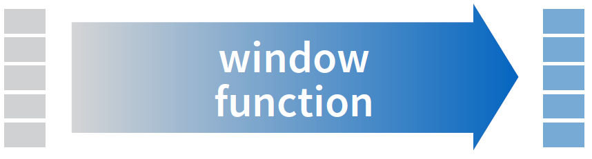

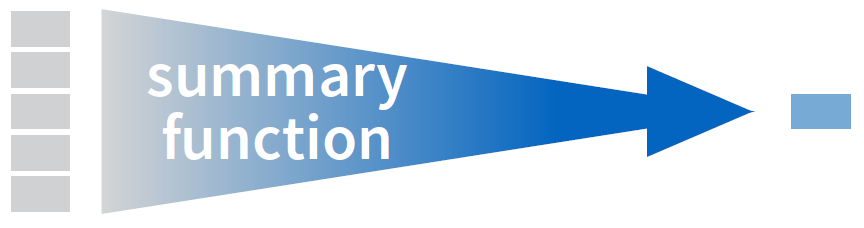

## Generating New Data

A common situation, creating composites of existing variables.

```r
bball = bball %>%
  mutate(trueShooting = PTS / (2 * (FGA + (.44 * FTA))),
         effectiveFG = (FG + (.5 * X3P)) / FGA,
         shootingDif = trueShooting - FG.)

summary(select(bball, shootingDif))  # select and others don't have to be piped to use
```

```
##   shootingDif
##  Min.   :-0.08645
##  1st Qu.: 0.04193
##  Median : 0.08016
##  Mean   : 0.07855
##  3rd Qu.: 0.11292
##  Max.   : 0.25000
##  NA's   :2
```

## Generating New Data

Note how we use the new variables

## Generating New Data

Sometimes we want to combine (or split) variables… unite creates a new variable as the string combination of others.

- essentially paste

```r
library(tidyr)
bball %>%
  unite("posTeam", Pos, Tm) %>%
  select(1:5) %>%
  head
```

```
##   Rk        Player posTeam Age  G
## 1  1    Quincy Acy  PF_NYK  24 68
## 2  2  Jordan Adams  SG_MEM  20 30
## 3  3  Steven Adams   C_OKC  21 70
## 4  4   Jeff Adrien  PF_MIN  28 17
## 5  5 Arron Afflalo  SG_TOT  29 78
## 6  5 Arron Afflalo  SG_DEN  29 53
```

## Generating New Data

separate does the opposite.

Separate player into first and last names based on where the space occurs.

```r
bball %>%
  separate(Player, into=c('firstName', 'lastName'), sep=' ') %>%
  select(1:5) %>%
  head
```

```
##   Rk firstName lastName Pos Age
## 1  1    Quincy      Acy  PF  24
## 2  2    Jordan    Adams  SG  20
## 3  3    Steven    Adams   C  21
## 4  4      Jeff   Adrien  PF  28
## 5  5     Arron  Afflalo  SG  29
## 6  5     Arron  Afflalo  SG  29
```

## Your turn

## Your turn

Data: state.x77

1. Convert to data.frame
2. Create a variable that's the log of population ( mutate )
3. Create **curLifeExp** as Life Expectancy (**Life.Exp**) + 5 ( mutate )
4. summarize the data ( summary )

## Example

```r
state.x77 %>%
  data.frame %>%
  mutate(popLog = log(Population),
         curLifeExp = Life.Exp+5) %>%
  summary
```

```
##    Population        Income       Illiteracy       Life.Exp         Murder          HS.Grad          Frost
##  Min.   :  365   Min.   :3098   Min.   :0.500   Min.   :67.96   Min.   : 1.400   Min.   :37.80   Min.   :  0.00
##  1st Qu.: 1080   1st Qu.:3993   1st Qu.:0.625   1st Qu.:70.12   1st Qu.: 4.350   1st Qu.:48.05   1st Qu.: 66.25
##  Median : 2838   Median :4519   Median :0.950   Median :70.67   Median : 6.850   Median :53.25   Median :114.50
##  Mean   : 4246   Mean   :4436   Mean   :1.170   Mean   :70.88   Mean   : 7.378   Mean   :53.11   Mean   :104.46
##  3rd Qu.: 4968   3rd Qu.:4814   3rd Qu.:1.575   3rd Qu.:71.89   3rd Qu.:10.675   3rd Qu.:59.15   3rd Qu.:139.75
##  Max.   :21198   Max.   :6315   Max.   :2.800   Max.   :73.60   Max.   :15.100   Max.   :67.30   Max.   :188.00
##       Area            popLog        curLifeExp
##  Min.   :  1049   Min.   :5.900   Min.   :72.96
##  1st Qu.: 36985   1st Qu.:6.984   1st Qu.:75.12
##  Median : 54277   Median :7.951   Median :75.67
##  Mean   : 70736   Mean   :7.863   Mean   :75.88
##  3rd Qu.: 81163   3rd Qu.:8.511   3rd Qu.:76.89
##  Max.   :566432   Max.   :9.962   Max.   :78.60
```

## Selecting Variables

## Selecting Variables

There are times when you do not want to look at the entire dataset, but instead want to focus on a few key variables.

Although this is easily handled in base R (as shown earlier), it can often more clearly accomplished using select in dplyr

The following lets us look at the data clearly, without having to create objects, use quotes etc.

```r
bball %>%
  select(Player, Tm, Pos, MP, trueShooting, effectiveFG, PTS) %>%
  summary
```

```
##     Player               Tm                Pos                  MP        trueShooting    effectiveFG
##  Length:651         Length:651         Length:651         Min.   :   1   Min.   :0.000   Min.   :0.0000
##  Class :character   Class :character   Class :character   1st Qu.: 272   1st Qu.:0.470   1st Qu.:0.4400
##  Mode  :character   Mode  :character   Mode  :character   Median : 896   Median :0.520   Median :0.4800
##                                                           Mean   :1042   Mean   :0.506   Mean   :0.4729
##                                                           3rd Qu.:1674   3rd Qu.:0.560   3rd Qu.:0.5200
##                                                           Max.   :2981   Max.   :1.060   Max.   :1.0000
##                                                                          NA's   :2       NA's   :2
##       PTS
##  Min.   :   0.0
##  1st Qu.:  90.0
##  Median : 308.0
##  Mean   : 428.1
##  3rd Qu.: 658.0
##  Max.   :2217.0
##
```

## Selecting Variables

That works great, but now we need to drop some of those variables to look at correlations.

```r
scoringDat = bball %>%
  select(Player, Tm, Pos, MP, trueShooting, effectiveFG, PTS)

scoringDat %>%
  select(-Player, -Tm, -Pos) %>%
  cor(use='complete') %>%
  round(2)
```

```
##                MP trueShooting effectiveFG  PTS
## MP           1.00         0.34        0.30 0.93
## trueShooting 0.34         1.00        0.96 0.33
## effectiveFG  0.30         0.96        1.00 0.27
## PTS          0.93         0.33        0.27 1.00
```

## Selecting Variables

Sometimes, we have a lot of variables to select. If they have a common naming scheme, this becomes very easy.

```r
bball %>%
  select(Player, contains("3P"), ends_with("RB")) %>%
  arrange(desc(TRB)) %>%
  head
```

```
##           Player X3P X3PA X3P.1 ORB DRB  TRB
## 1 DeAndre Jordan   1    4 0.250 397 829 1226
## 2 Andre Drummond   0    2 0.000 437 667 1104
## 3      Pau Gasol  12   26 0.462 220 699  919
## 4 Tyson Chandler   0    0    NA 294 570  864
## 5 Nikola Vucevic   2    6 0.333 238 572  810
## 6    Rudy Gobert   0    2 0.000 265 510  775
```

## Filtering Observations

## Filtering Observations

Recall this bit of code?

```r
bball = html(url) %>%
  html_nodes("table#totals") %>%
  html_table %>%
  data.frame %>%
  filter(Rk != "Rk")
```

You will notice the filter line at the end.

We sometimes want to see a very specific portion of the data.

## Filtering Observations

- filter returns rows with matching conditions.
- slice allows for a numeric indexing approach.
- Say we want too look at forwards over the age of 35…

```r
bball %>%
  filter(Age > 35, Pos == "SF" | Pos == "PF")
```

- or the first 10 rows…

```r
bball %>%
  slice(1:10)
```

## Filtering Observations

This can be done with things that are created on the fly…

```r
bball %>%
  unite("posTeam", Pos, Tm) %>%
  filter(posTeam == "PF_SAS") %>%
  arrange(desc(PTS/PF)) %>%
  select(1:10)
```

```
##    Rk         Player posTeam Age  G GS   MP  FG FGA   FG.
## 1 137     Tim Duncan  PF_SAS  38 77 77 2227 419 819 0.512
## 2 126     Boris Diaw  PF_SAS  32 81 15 1984 291 632 0.460
## 3  56    Matt Bonner  PF_SAS  34 72 19  935  94 230 0.409
## 4  26     Jeff Ayres  PF_SAS  27 51  0  383  55  95 0.579
## 5 187 JaMychal Green  PF_SAS  24  4  0   25   4   7 0.571
```

## Your turn

## Your turn

A brief exercise:

1. filter the iris data set to only the virginica species ( == )
2. show only **Petal.Length** and **Petal.Width** variables ( select )
3. bonus: redo, but instead, filter if the ratio of **Petal.Length** to **Petal.Width** is greater than 5. Which species do these observations belong to?

## Example

```r
iris %>%
  filter(Petal.Length/Petal.Width > 5) %>%
  summary
```

```
##   Sepal.Length    Sepal.Width     Petal.Length    Petal.Width           Species
##  Min.   :4.300   Min.   :2.900   Min.   :1.100   Min.   :0.1000   setosa    :34
##  1st Qu.:4.800   1st Qu.:3.100   1st Qu.:1.400   1st Qu.:0.2000   versicolor: 0
##  Median :5.000   Median :3.400   Median :1.450   Median :0.2000   virginica : 0
##  Mean   :4.982   Mean   :3.382   Mean   :1.456   Mean   :0.1882
##  3rd Qu.:5.200   3rd Qu.:3.575   3rd Qu.:1.500   3rd Qu.:0.2000
##  Max.   :5.800   Max.   :4.200   Max.   :1.900   Max.   :0.3000
```

## Reshaping Data

## Reshaping Data

Depending upon your analytical or visualization needs, sometimes you need to reshape your data.

Reshaping can take many forms. You might need to reshape your data from wide format to long format.

Or, maybe you need to split or combine variables.

Either way, R has you covered.

## Wide to Long

We are going to use the tidyr package to make this data go from wide to long.

The function of note is gather.

- **key** is the new variable name, a factor whose labels are the variable names of the wide format
- **value** is the name of the variable that will contain their values

```r
bballLong = bball %>%
  select(Player, Tm, FG., X3P, X2P.1, trueShooting, effectiveFG) %>%
  rename(fieldGoalPerc = FG., threePointPerc = X3P, twoPointPerc = X2P.1) %>%
  mutate(threePointPerc = threePointPerc/100) %>%
  gather(key = 'vitalInfo', value = 'value', -Tm, -Player)

bballLong %>% head
```

```
##          Player  Tm     vitalInfo value
## 1    Quincy Acy NYK fieldGoalPerc 0.459
## 2  Jordan Adams MEM fieldGoalPerc 0.407
## 3  Steven Adams OKC fieldGoalPerc 0.544
## 4   Jeff Adrien MIN fieldGoalPerc 0.432
## 5 Arron Afflalo TOT fieldGoalPerc 0.424
## 6 Arron Afflalo DEN fieldGoalPerc 0.428
```

## Long to wide

Going the reverse direction

```r
bballLong %>%
  spread(vitalInfo, value) %>%
  head
```

```
##         Player  Tm fieldGoalPerc threePointPerc twoPointPerc trueShooting effectiveFG
## 1   A.J. Price CLE         0.265           0.00        0.391         0.30        0.26
## 2   A.J. Price IND         0.438           0.15        0.480         0.54        0.52
## 3   A.J. Price PHO         0.214           0.00        0.429         0.21        0.21
## 4   A.J. Price TOT         0.372           0.15        0.450         0.45        0.43
## 5 Aaron Brooks CHI         0.421           1.21        0.442         0.53        0.50
## 6 Aaron Gordon ORL         0.447           0.13        0.500         0.52        0.48
```

## Grouping and Summarizing Data

## Grouping and Summarizing Data

When working with data, a very common task is to look at descriptive statistics for various groups.

We can use group_by to make this straightforward.

```r
scoringDat %>%
  group_by(Pos) %>%
  summarize(meanTrueShooting = mean(trueShooting, na.rm = TRUE))
```

```
## Source: local data frame [11 x 2]
##
##      Pos meanTrueShooting
##    (chr)            (dbl)
## 1      C        0.5460638
## 2     PF        0.5120690
## 3  PF-SF        0.4600000
## 4     PG        0.4815493
## 5  PG-SG        0.5100000
## 6     SF        0.5083761
## 7  SF-PF        0.5500000
## 8  SF-SG        0.5500000
## 9     SG        0.4951748
## 10 SG-PG        0.5450000
## 11 SG-SF        0.4700000
```

## Your Turn

## Putting it all together

?state.x77

Using one pipe sequence

1. convert state.x77 (a base R object) to a data frame ( data.frame )
2. create a new variable called **Region** that is equal to state.region ( mutate )
3. create a new variable called **State** that is equal to state.name
4. filter only if Population is greater than 1000 (thousands)
5. select **Region** and variables beginning with I
6. group by **Region** ( group_by )
7. summarize **Income**, **Illiteracy** or **Both**, using the mean function

## Example

```r
state.x77 %>%
  data.frame %>%
  mutate(Region = state.region,
         State = state.name) %>%
  filter(Population > 1000) %>%
  select(Region, starts_with('I')) %>%
  group_by(Region) %>%
  summarize(meanInc=mean(Income),
            meanIll=mean(Illiteracy))
```

```
## Source: local data frame [4 x 3]
##
##          Region meanInc  meanIll
##          (fctr)   (dbl)    (dbl)
## 1     Northeast  4731.0 1.066667
## 2         South  3958.8 1.793333
## 3 North Central  4607.9 0.710000
## 4          West  4525.0 1.085714
```

## Nothin's gonna stop the flow

## More with pipes

Recap thus far:

%>% : Passes the prior object to the function after the pipe

- x %>% f same as f(x)
- Example:

```r
iris %>% head
```

```
##   Sepal.Length Sepal.Width Petal.Length Petal.Width Species
## 1          5.1         3.5          1.4         0.2  setosa
## 2          4.9         3.0          1.4         0.2  setosa
## 3          4.7         3.2          1.3         0.2  setosa
## 4          4.6         3.1          1.5         0.2  setosa
## 5          5.0         3.6          1.4         0.2  setosa
## 6          5.4         3.9          1.7         0.4  setosa
```

```r
head(iris)
```

```
##   Sepal.Length Sepal.Width Petal.Length Petal.Width Species
## 1          5.1         3.5          1.4         0.2  setosa
## 2          4.9         3.0          1.4         0.2  setosa
## 3          4.7         3.2          1.3         0.2  setosa
## 4          4.6         3.1          1.5         0.2  setosa
## 5          5.0         3.6          1.4         0.2  setosa
## 6          5.4         3.9          1.7         0.4  setosa
```

## More with pipes

%$% : Exposes the names in the prior to the function after

- x %$% y(a, b) same as y(x$a, x$b)
- Example:

```r
iris %$% lm(Sepal.Length ~ Sepal.Width)
```

```
##
## Call:
## lm(formula = Sepal.Length ~ Sepal.Width)
##
## Coefficients:
## (Intercept)  Sepal.Width
##      6.5262      -0.2234
```

## More with pipes

%T>% : Passes the prior object to the function after the pipe and what follows

- x %T>% y %>% z is the same as x %>% y & x %>% z

## More with pipes

Example:

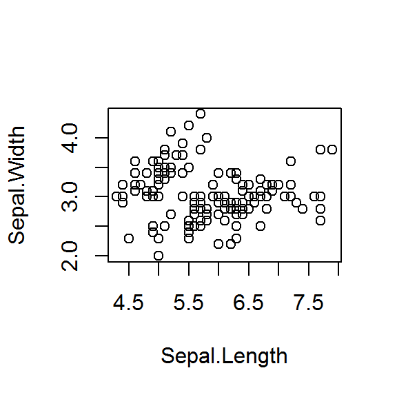

```
##   Sepal.Length    Sepal.Width
##  Min.   :4.300   Min.   :2.000
##  1st Qu.:5.100   1st Qu.:2.800
##  Median :5.800   Median :3.000
##  Mean   :5.843   Mean   :3.057
##  3rd Qu.:6.400   3rd Qu.:3.300
##  Max.   :7.900   Max.   :4.400
```

```r
iris %>% select(Sepal.Length, Sepal.Width) %T>% plot %>%summary
```

## More with pipes

Unfortunately the T pipe does not allow for printable results.

- Works:

```r
iris %>% select(Sepal.Length, Sepal.Width) %T>% plot %>% summary
```

- Provides no summary:

```r
iris %>% select(Sepal.Length, Sepal.Width) %T>% summary %>% plot
```

- Somewhat limiting in my opinion.

## More with pipes

%<>% : assigns to former object the operations that follow

- Example:

```r
iris2 = iris
iris2 %<>% rnorm(10)
iris2
```

```
## [1] 10.518973 10.931990  9.749753 11.258531 11.926553
```

## Piping for Visualization

## Piping for Visualization

One of the advantages to piping is that it's not limited to dplyr style data management functions.

*Any* R function can be potentially piped to, and we've seen several examples so far.

```r
data.frame(y=rnorm(100), x=rnorm(100)) %$%
  lm(y ~ x)
```

```
##
## Call:
## lm(formula = y ~ x)
##
## Coefficients:
## (Intercept)            x
##    0.005074    -0.039820
```

This facilitates data exploration

## htmlwidgets

Many newer visualization packages take advantage of piping as well.

htmlwidgets is a package that makes it easy to use R to create javascript visualizations.

- i.e. what you see everywhere on the web.

The packages using it typically are pipe-oriented and produce interactive plots.

## Some htmlwidgets packages

- leaflet
  - maps with OpenStreetMap
- dygraphs
  - time series visualization
- networkD3
  - Network visualization with D3
- DT
  - Tabular data via DataTables
- rthreejs
  - 3D graphics

## leaflet

```r
leaflet() %>%
  setView(lat=42.2655, lng=-83.7485, zoom=15) %>%
  addTiles() %>%
  addPopups(lat=42.2655, lng=-83.7485, 'Hi!')
```

[interactive chart not shown]

## dygraphs

Dygraphs requires time-series objects

```r
#use current poll data code from home
library(dygraphs)
data(UKLungDeaths)
cbind(ldeaths, mdeaths, fdeaths) %>%
  dygraph()
```

[interactive chart not shown]

## networkD3

```r
library(networkD3)
forceNetwork(Links = netlinks, Nodes = netnodes, Source = "source",
             Target = "target", Value = "value", NodeID = "name",
             Nodesize = "size", Group = "group", opacity = 0.4, legend = T,
             colourScale = JS("d3.scale.category10()"))
```

[interactive chart not shown]

## data table

```r
library(DT)
datatable(select(bball, 1:5), rownames=F)
```

| Rk | Player | Pos | Age | Tm |
| --- | --- | --- | --- | --- |
| 1 | Quincy Acy | PF | 24 | NYK |
| 2 | Jordan Adams | SG | 20 | MEM |
| 3 | Steven Adams | C | 21 | OKC |
| 4 | Jeff Adrien | PF | 28 | MIN |
| 5 | Arron Afflalo | SG | 29 | TOT |
| 5 | Arron Afflalo | SG | 29 | DEN |
| 5 | Arron Afflalo | SG | 29 | POR |
| 6 | Alexis Ajinca | C | 26 | NOP |
| 7 | Furkan Aldemir | PF | 23 | PHI |
| 8 | Cole Aldrich | C | 26 | NYK |

[output cut: 641 more lines]

## ggvis

ggvis is a general purpose visualization package

- the successor to ggplot2 to provide interactivity
- ggplot2 is still great for static plots

Reminder of what's in the data:

```r
bballLong %>% head
```

```
##          Player  Tm     vitalInfo value
## 1    Quincy Acy NYK fieldGoalPerc 0.459
## 2  Jordan Adams MEM fieldGoalPerc 0.407
## 3  Steven Adams OKC fieldGoalPerc 0.544
## 4   Jeff Adrien MIN fieldGoalPerc 0.432
## 5 Arron Afflalo TOT fieldGoalPerc 0.424
## 6 Arron Afflalo DEN fieldGoalPerc 0.428
```

## ggvis

ggvis works by starting with a base, to which subsequent layers are added, with additional options if needed.

```r
bballLong %>%
  group_by(Tm, vitalInfo) %>%
  summarize(avg = mean(value)) %>%
  ggvis(x=~Tm, y=~avg) %>%
  layer_points(fill = ~vitalInfo) %>%
  add_axis("x", grid=F, properties = axis_props(labels=list(angle=90, fill='gray'),
                                                axis=list(stroke=NA),
                                                ticks=list(stroke=NA))
           ) %>%
  add_axis('y', grid=F)
```

[output not shown]

## ggvis

## Your turn

## Your turn

Using ggvis and the data set mtcars, we'll create a grouped scatterplot without creating any new objects.

## Example

```r
mtcars %>%
  mutate(amFactor = factor(am, labels=c('auto', 'manual'))) %>%
  group_by(amFactor) %>%
  ggvis(x=~wt, y=~mpg) %>%
  layer_points(fill=~amFactor) %>%
  layer_smooths(stroke=~amFactor)
```

## For fun

Add a little waggle to your plot.

```r
span = waggle(0.5, 2)
mtcars %>%
  mutate(amFactor = factor(am, labels=c('auto', 'manual'))) %>%
  group_by(amFactor) %>%
  ggvis(x=~wt, y=~mpg) %>%
  layer_points(fill=~amFactor) %>%
  layer_smooths(stroke=~amFactor, span=span)
```

## Wrap up

Note that much of the functionality you see is in base R

- with, within, tapply etc.

What you now have is a more straightforward way to do those operations.

Think of these packages as organizational and exploratory tools.

Use them to bring clarity to code.

Use them to explore your data more easily whether for visualization or modeling.

With more use, the easier it gets, and the more you can do.

## Further Resources

[Data wrangling cheatsheet](https://www.rstudio.com/wp-content/uploads/2015/02/data-wrangling-cheatsheet.pdf)

magrittr

[ggvis](http://ggvis.rstudio.com/)

## Thanks!

Michael Clark  
Consulting for Statistics, Computing & Analytics Research  
Advanced Research Computing  
University of Michigan

With notable assistance from:

Seth Berry  
Center for Social Research  
Notre Dame Research  
University of Notre Dame

[figure not shown]